# Riyadh Map Data Wrangling with MongoDB

## Project Overview:

Choosing any area of the world in https://www.openstreetmap.org and use data munging techniques, such as assessing the quality of the data for validity, accuracy, completeness, consistency and uniformity, to clean the OpenStreetMap data for a part of the world and all of this using pyhton programming language and MongoDB.

## Dataset:

The selected dataset in this project is of Riyadh city, Saudi Arabia’s capital and main financial hub, is on a desert plateau in the country’s center. Business district landmarks include the 302m-high Kingdom Centre, with a sky bridge connecting 2 towers, and 267m-high Al Faisaliah Centre, with a glass-globe summit.

I choose this city because I live in it.

Dataset Size: 80315642

Downloaded from https://mapzen.com/data/metro-extracts/

##### Note: This dataset for Riyadh city not Riyadh region

## Riyadh:

- https://en.wikipedia.org/wiki/Riyadh

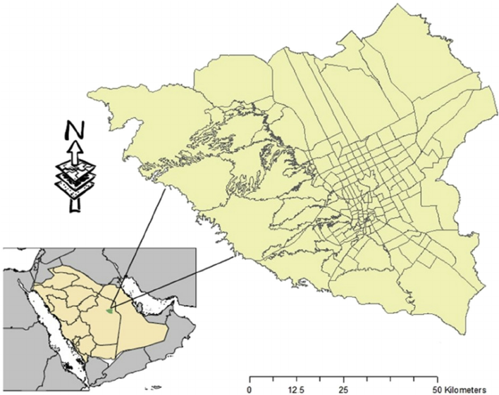

```python
from IPython.display import Image
Image("https://www.researchgate.net/profile/Kh_Md_Nahiduzzaman/publication/279518448/figure/fig1/AS:294286869450752@1447174865643/Fig-1-Location-of-Riyadh-in-the-Kingdom-of-Saudi-Arabia.png", width ="400")
```

## Data Audit:

### Issues:

> I start working on the dataset and exploring the data with focusing on the streets and postal codes and I notced many problems:
> - Street and Road names.
> - Postal codes.

#### Streets and Roads:

> - 1) St. and St (For street).
> - 2) Rd. and Rd (For Road).
> - 3) Some roads or streets have only the name (without specifying the type like "road,street,way").

> Example on these:
> - 1) "Takhassusi St." fixed to "Takhassusi Street"
> - 2) "Omar Ibn Al Khattab Rd" fixed to "Omar Ibn Al Khattab Road"
> - 3) Can't be fixed because no one know if this is a road, street or a way! .

#### Postal codes:

> - Riyadh city must have postal codes of 5 numbers only (ex:12345).
> - 1) Some of postal codes in the data have more than 5 numbers like "12345 1234", the first part of this format is the postal code and the secound part of it which is 4 numbers is called the additional number.
> - 2) Some of postal codes in the data have less than 5 numbers like "1234", which is basically wrong and can't be fixed.

> Example on these:
> - 1) "12783-8458" fixed to "12783".
> - 2) "7069" > Can't be fixed.

## Analysis:

### Data Overview:

##### Some statistics about Riyadh city map dataset using mongo shell on the terminal instead of python:

###### Dataset size:

> - Before auditing the data: 80.3 MB (OSM)
> - After auditing the data: 113.4 MB (JSON)

###### Database Stats:

> db.stats( )
> - "db" : "mydb",
> - "collections" : 1,
> - "views" : 0,
> - "objects" : 420466,
> - "avgObjSize" : 239.01057873882786,
> - "dataSize" : 100495822,
> - "storageSize" : 30617600,
> - "numExtents" : 0,
> - "indexes" : 1,
> - "indexSize" : 3952640,
> - "ok" : 1

**Number of documents: 420466**

> db.getCollection('RiyadhMap').find().count()

**Number of nodes: 342776**

> db.getCollection('RiyadhMap').find({"type":"node"}).count()

**Number of ways: 77682**

> db.getCollection('RiyadhMap').find({"type":"way"}).count()

**Number of unique users: 766**

> db.getCollection('RiyadhMap').distinct("created.user").length

**Top 1 contributing user: Seandebasti**

> db.RiyadhMap.aggregate([

> ```
> {$match: {'created.user': {$exists: 1} }},
>  {$group: {_id: '$created.user', 'count': {$sum: 1}}},
>  {$sort: {'count': -1}},
>  {$limit: 10}
> ```

> ])

**Top 3 contributors: Seandebasti, mustafakamil and Rub21**

> db.RiyadhMap.aggregate([

> ```
> {$match: {'created.user': {$exists: 1} }},
>  {$group: {_id: '$created.user','count':{$sum: 1}}},
>  {$sort: {'count': -1}},
>  {$limit: 10}
> ```

> ])
> - { "_id" : "Seandebasti", "count" : 159556 }
> - { "_id" : "mustafakamil", "count" : 62487 }
> - { "_id" : "Rub21", "count" : 42597 }
> - { "_id" : "bauma", "count" : 29023 }
> - { "_id" : "Cicerone", "count" : 25734 }
> - { "_id" : "Khaled AlOtaibi", "count" : 10538 }
> - { "_id" : "keepright! ler", "count" : 9074 }
> - { "_id" : "Dugoon", "count" : 8784 }
> - { "_id" : "Majdi", "count" : 5221 }
> - { "_id" : "Rudy355", "count" : 4435 }

**Top amenity: place_of_worship**

> db.RiyadhMap.aggregate([

> ```
> {$match: {'amenity': {$exists: 1} }},
>  {$group: {_id: '$amenity', count: {$sum: 1}}},
>  {$sort: {'count': -1}},
>  {$limit: 10}
> ```

> ])
> - { "_id" : "place_of_worship", "count" : 1069 }
> - { "_id" : "parking", "count" : 806 }
> - { "_id" : "fuel", "count" : 272 }
> - { "_id" : "school", "count" : 267 }
> - { "_id" : "restaurant", "count" : 265 }
> - { "_id" : "embassy", "count" : 87 }
> - { "_id" : "hospital", "count" : 85 }
> - { "_id" : "fast_food", "count" : 77 }
> - { "_id" : "atm", "count" : 75 }
> - { "_id" : "bank", "count" : 73 }

## Python Code:

```python
# import required libraries:
import pprint
import re
import codecs
import xml.etree.cElementTree as ET
import json
from collections import defaultdict
```

###### Gloable varibles:

```python
problem_chars = re.compile(r'[=\+/&<>;\'"\?%#$@\,\. \t\r\n]')
street_types = re.compile(r'\b\S+\.?$', re.IGNORECASE)

OSMFILE = "/Users/Abdulaziz/Data Analyst Nanodegree/All Projects/Project_3/Riyadh.osm"
street_type_re = re.compile(r'\b\S+\.?$', re.IGNORECASE)
CREATED = ["version", "changeset", "timestamp", "user", "uid"]


expected = ["Street", "Road"]
# In the dataset there is only these expected types or there are missing
# But the arabic stareet name tag it could contains the correct one.

street_mapping = { "St": "Street",
            "Rd" :"Road",
            "RD":"Road",
            "street":"Street"
}

fixed_street_names = []
bad_postal_codes = []
fixed_postal_codes = []
```

###### Auditing The Street names:

```python
def is_street_name(address_key):
    return address_key == 'addr:street'
#we check first if the tag is a street

def isEnglish(s):
    try:
        s.encode(encoding='utf-8').decode('ascii')
    except UnicodeDecodeError:
        return False
    else:
        return True
#We check if the street name in arabic or english(arabic is ignored)

def audit_street_type(street_name):
    """Check the street name """
    match = street_types.search(street_name)
    if match:
        street_type = match.group()
        if street_type not in expected and isEnglish(street_name):
            return update_street_name(street_name, street_mapping)


    return street_name

def update_street_name(name, mapping):
    """Fix the name and return or return it as it is if it's ok"""
    for key in mapping.keys():
        if re.search(key, name):
            name = re.sub(key, mapping[key], name)
            fixed_street_names.append(name)

    return name
```

###### Auditing Postal Codes:

```python
def is_postal_code(address_key):
    return address_key == 'addr:postcode'
#we check first if the tag is a postal code




def audit_postal_code(postal_code):

    if len(postal_code) == 5 and postal_code.isdigit() :
        return postal_code

    bad_postal_codes.append(postal_code)

    # fix the code by taking only first 5 chars if it's more than 5 chars
    # this will not solve all problems but it'll reduce it.

    if len(postal_code) > 5 :
        postal_code = postal_code[:5]
        fixed_postal_codes.append(postal_code)

    return postal_code
```

###### Importing the data into mongo database:

- After cleaning the data and export it as JSON file we stored it in MongoDB like the following:

  > mongoimport --db mydb --collection RiyadhMap --drop --file Riyadh.osm.json
> - Database name: mydb
> - Collection name: RiyadhMap

###### Complete python auditing code:

> https://drive.google.com/open?id=0Bz_0XKKPAnSFeEFYU0RKRmdGaE0

## Additional analysis and suggestions:

After a lot of analysis and focusing on "amenity" field I notice that there is alot of places without a name for example if we are going to see all "fuel" places and their names we'll see that the majority of fuel stations have null values instead of its name.

> db.RiyadhMap.aggregate([

> ```
> {$match: {amenity: 'fule' }},
>  {$group: {_id: '$name', count: {\$sum: 1}}},
>  {$sort: {'count': -1}},
>  {$limit: 10}
> ```

> ])

**Note: fule stations most of them has Arabic name.**

> - { "_id" : null, "count" : 232 }
> - { "_id" : "سهل", "count" : 3 }
> - { "_id" : "نفط", "count" : 3 }
> - { "_id" : "الدريس", "count" : 3 }
> - { "_id" : "محطة الدريس", "count" : 3 }
> - { "_id" : "محطة وقود", "count" : 2 }
> - { "_id" : "محطة", "count" : 2 }
> - { "_id" : "Station Service E. Leclerc", "count" : 1 }
> - { "_id" : "محطة الجزيره", "count" : 1 }
> - { "_id" : "رعد الجنوب", "count" : 1 }

**Now let's check the what are the most famus 10 fast food restaurants:**

> db.RiyadhMap.aggregate([

> ```
> {$match: {amenity: 'fast_food' }},
>  {$group: {_id: '$name', count: {\$sum: 1}}},
>  {$sort: {'count': -1}},
>  {$limit: 10}
> ```

> ])
> - { "_id" : null, "count" : 11 }
> - { "_id" : "McDonald's", "count" : 10 }
> - { "_id" : "Kudu", "count" : 7 }
> - { "_id" : "Burger King", "count" : 5 }
> - { "_id" : "Herfy", "count" : 3 }
> - { "_id" : "Subway", "count" : 3 }
> - { "_id" : "McDonalds", "count" : 2 }
> - { "_id" : "ماكدونالدز", "count" : 2 }
> - { "_id" : "Hardees", "count" : 2 }
> - { "_id" : "Pizza Hut", "count" : 2 }

> We can see McDonald's has 10 + 2 + 2 = 14 Places and the names are written in different formats and languages (English and Arabic):
> - McDonald's = 10
> - McDonalds = 2
> - ماكدونالدز = 2

### Suggestions:

> After analyzing this data, I found out that all its problems because of human entry which consist of the format used for both streets and postal codes and the differint languages used in this data.

> We could fix the data issues by some of suggestions I came up with:
> > - Using standard language.
> > - Standardizing the postal code and street names format.
> > - Collecting the data from credible source.

## Conclusion:

> We have cleaned a reasnable amount of the data which is required for this project. But, there are lots of improvement needed in the dataset. The dataset contains very less amount of additional information in English and it contains very old information which is now incomparable to that of Google Maps or Bing Maps.

> Since the city is an Arabain city, the most valuable data was represented in Arabic langauge which contains alot of credible information, in addition it's not possible to use in this project since it's not in English.

## References:

- https://www.openstreetmap.org/node/315358390#map=10/24.7612/46.7400
- https://mapzen.com/data/metro-extracts/
- https://docs.python.org/3/
- http://wiki.openstreetmap.org/wiki/OSM_XML
- https://docs.mongodb.org/manual
- https://github.com/
- https://en.wikipedia.org/wiki/Riyadh
- https://stackoverflow.com